# Santa Barbara Urchins

Russell Fager

10/22/2021

## Overview

This code wrangles then visualizes data for red and purple urchins observed at 5 sites along the Santa Barbara coast.

Data Citation: Reed, D. 2020. SBC LTER: Reef: Long-term experiment: Kelp removal: Urchin size frequency distribution ver 20. Environmental Data Initiative. https://doi.org/10.6073/pasta/5a1e9ef03aa47bd2225c0bb98a02a63b.

### Setup

Attach packages

```r
knitr::opts_chunk$set(echo = TRUE, message = FALSE, warning = FALSE)

library(tidyverse)
library(here)
library(janitor)
library(kableExtra)
library(DT)
library(lubridate)
```

### Read in the data

read in the urchins.csv data

```r
urchins_data <- read_csv(here("data", "urchins.csv"))
```

### Data Wrangling

clean names to lower snake case

```r
urchins_data_clean <- urchins_data %>%  clean_names()
```

## SECTION 1

### Data Visualization

Size comparisons of purple and red urchins

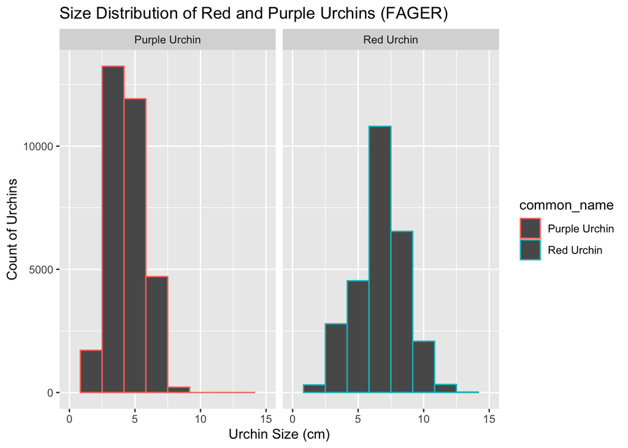

```r
ggplot(data = urchins_data_clean, aes(x = size, color = common_name)) +
  geom_histogram(bins = 10)+
  facet_wrap(~common_name)+
  xlim(0, 15)+
  labs(x = "Urchin Size (cm)",
       y = "Count of Urchins",
       title = "Size Distribution of Red and Purple Urchins (FAGER)")
```

*Figure 1. This chart shows the distribution of sizes of red and purple sea urchins (measured to the nearest 0.5 cm) along the Santa Barbara coast. Data from Reed, D. 2020.*

### Descriptive Statistics Table

Here is a summary table showing the mean, median, standard deviation, and sample size for purple and red urchins from the Reed, D. 2020 data recorded by Santa Barbara Coastal Long Term Ecological Research program divers.

```r
urchin_stats <- urchins_data_clean %>%
  group_by(common_name) %>%
  summarize(
    n = n(),
    mean = mean(size),
    sd = sd(size),
    median = median(size))%>%
  kable(caption = "Summary Statistics of Red and Purple Urchins Size", digits = 2, col.names = c("species",
                       "Sample Size",
                       "Mean Size (cm)",
                       "Standard Deviation (cm)",
                       "Median Size (cm)")) %>%
  kable_styling(full_width = FALSE)
urchin_stats
```

Summary Statistics of Red and Purple Urchins Size

| species | Sample Size | Mean Size (cm) | Standard Deviation (cm) | Median Size (cm) |
| --- | --- | --- | --- | --- |
| Purple Urchin | 31805 | 4.47 | 1.18 | 4.5 |
| Red Urchin | 27408 | 6.78 | 1.89 | 7.0 |

## Section 2

### Data Wrangling

This section explores purple urchin counts by site and year

```r
purple_urchins <- urchins_data_clean %>%
  filter(common_name == "Purple Urchin") %>%
  mutate(date_new = mdy(date)) %>%
  mutate(year = year(date_new)) %>%
  mutate(site_full = case_when(
    site == "NAPL" ~ "Naples Reef",
    site == "AQUE" ~"Arroyo Quemado Reef",
    site == "CARP" ~ "Carpinteria Reef",
    site == "MOHK" ~ "Mohawk Reef",
    site == "IVEE" ~ "Isla Vista Reef"

  ))
```

The code below stores a table containing the total number of purple urchins observed by site and year.

```r
purple_urchins_summary <- purple_urchins  %>%
  group_by(site_full, year) %>%
  summarize(urchin_count = n())
```

### Data Visualization

The code below creates a chart showing the number of purple urchins recorded at each site per year.

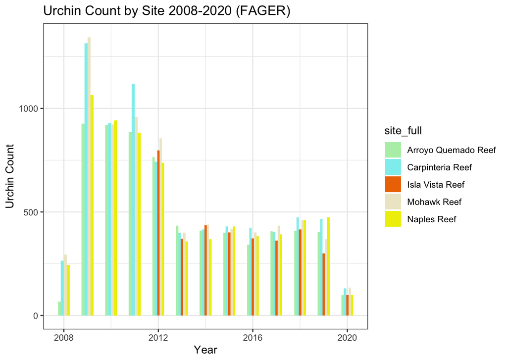

```r
ggplot(data = purple_urchins_summary, aes(x = year, y = urchin_count)) +
  geom_col(aes(fill = site_full),
           width = 0.5,
           position = "dodge")+
  scale_fill_manual(values = c("darkseagreen2", "darkslategray2", "darkorange2", "cornsilk2", "yellow2"))+
  theme_bw ()+
  labs(x = "Year",
       y = "Urchin Count",
       title = "Urchin Count by Site 2008-2020 (FAGER)")
```

*Figure 3. This chart shows the number of purple urchins recorded at each site per year*